# LatinR 2026: integración reproducible de datos satelitales y paneles espaciales en R

Una aplicación de PM₂.₅ para Colombia, 2012–2022

Edwin Fernando Muñoz Chipatecua — Universidad Externado de Colombia

# Presentación

Este documento reúne los principales resultados del trabajo *Integración reproducible de datos satelitales y paneles espaciales en R: una aplicación de PM₂.₅ para Colombia*, desarrollado para el periodo 2012–2022.

Se presentan los procedimientos utilizados para integrar la información, verificar la consistencia de los datos y analizar la distribución temporal y espacial de las concentraciones de PM₂.₅ en Colombia. También se incluye una exploración de su relación estadística con la mortalidad respiratoria.

Las tablas y figuras permiten examinar los resultados con mayor detalle. El código en R puede consultarse directamente en cada sección.

# 1. Integración y auditoría del panel

```r
ruta <- file.path("datos","14_panel_departamental_integrado_2012_2022.csv")
if (!file.exists(ruta)) stop("Extraiga el ZIP completo. Falta: ",ruta)
panel <- read.csv(ruta, check.names=FALSE, fileEncoding="UTF-8",
                  stringsAsFactors=FALSE, na.strings=c("","NA"))
cat("Filas:",nrow(panel)," | Columnas:",ncol(panel),"\n")
```

```
## Filas: 363  | Columnas: 23
```

```r
print(names(panel))
```

```
##  [1] "dep_key"                           "anio"
##  [3] "Departamento"                      "PM25_area_valida"
##  [5] "PM25_media_municipal"              "Poblacion"
##  [7] "area_valida_total_km2"             "n_unidades_gadm"
##  [9] "n_unidades_cobertura_baja"         "cobertura_minima_pct"
## [11] "viento_media_ms"                   "area_cubierta_km2"
## [13] "cobertura_viento_pct"              "n_celdas_validas"
## [15] "estado_cobertura"                  "Defunciones_IRA_candidata"
## [17] "Tasa_IRA_100mil_original"          "Tasa_IRA_100mil_candidata"
## [19] "Codigo_causa_DANE"                 "estado_dato_IRA"
## [21] "fuente_IRA_2016"                   "comparable_IRA_109_108_verificada"
## [23] "estado_viento"
```

```r
necesarias <- c("dep_key","anio","Departamento","PM25_area_valida",
 "viento_media_ms","Poblacion","Defunciones_IRA_candidata",
 "Tasa_IRA_100mil_candidata","Codigo_causa_DANE",
 "comparable_IRA_109_108_verificada")
faltantes <- setdiff(necesarias,names(panel))
if(length(faltantes)) stop("Faltan columnas: ",paste(faltantes,collapse=", "))
auditoria <- data.frame(
 Control=c("Observaciones","Departamentos","Años","Duplicados departamento-año",
           "PM2.5 faltante","Viento faltante"),
 Resultado=c(nrow(panel),length(unique(panel$dep_key)),
 length(unique(panel$anio)),sum(duplicated(panel[c("dep_key","anio")])),
 sum(is.na(panel$PM25_area_valida)),sum(is.na(panel$viento_media_ms))))
knitr::kable(auditoria,caption="Controles recalculados del CSV")
```

Controles recalculados del CSV

| Control | Resultado |
| --- | --- |
| Observaciones | 363 |
| Departamentos | 33 |
| Años | 11 |
| Duplicados departamento-año | 0 |
| PM2.5 faltante | 0 |
| Viento faltante | 11 |

```r
stopifnot(nrow(panel)==363, length(unique(panel$dep_key))==33,
          identical(sort(unique(panel$anio)),2012:2022),
          !anyDuplicated(panel[c("dep_key","anio")]))
```

El panel departamental tiene **363 registros** (33 departamentos × 11 años). El panel municipal de PM₂.₅, construido previamente, tiene **12.309 registros** (1.119 municipios × 11 años). No son el mismo producto.

# 2. Procedimiento espacial documentado

**Decisión de procesamiento que conviene poder auditar.** Los datos ACAG están organizados en celdas; GADM delimita polígonos administrativos. La concentración territorial se calculó usando la superficie válida que cada celda comparte con el municipio. Así, una celda que apenas intersecta un municipio no recibe el mismo peso que otra que lo cubre extensamente.

La siguiente expresión documenta la regla implementada en los scripts originales (no se recalcula en este documento):

$$\widehat{PM}_{it} =
\frac{\sum_{c\in \mathcal{C}_i} PM_{ct}\,a_c f_{ic} I_{ct}}
{\sum_{c\in \mathcal{C}_i} a_c f_{ic} I_{ct}}.$$

Los siguientes gráficos permiten inspeccionar la evidencia de validación y la resolución espacial municipal. Son **salidas del procesamiento original**, no una extracción satelital ejecutada por este documento. La media por área representa concentración territorial, no exposición personal ni media ponderada por población.

### Verificación de los valores calculados

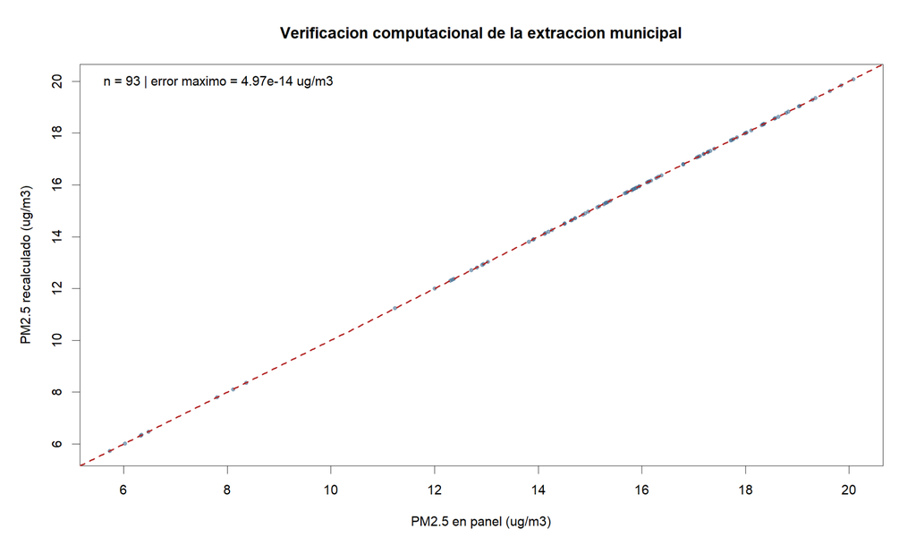

Verificación muestral de la consistencia de los valores calculados de PM₂.₅.

### Resolución espacial municipal

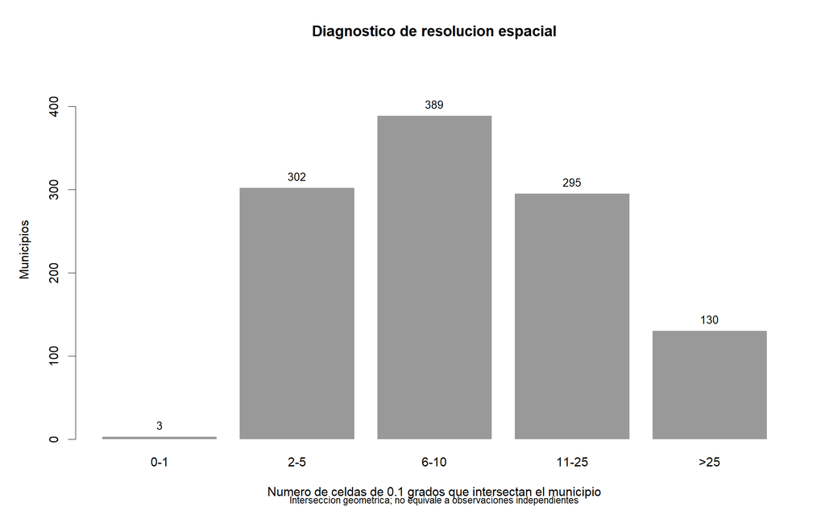

Distribución de la resolución espacial de los municipios en la agregación de PM₂.₅.

# 3. Evolución temporal y diferencias departamentales

```r
serie <- aggregate(PM25_area_valida~anio,panel,mean)
names(serie)[2] <- "media_pm25"
knitr::kable(serie,digits=3,
             caption="Promedio simple de los 33 promedios departamentales")
```

Promedio simple de los 33 promedios departamentales

| anio | media_pm25 |
| --- | --- |
| 2012 | 15.585 |
| 2013 | 14.542 |
| 2014 | 16.823 |
| 2015 | 15.815 |
| 2016 | 16.807 |
| 2017 | 16.074 |
| 2018 | 14.957 |
| 2019 | 17.529 |
| 2020 | 17.973 |
| 2021 | 15.041 |
| 2022 | 16.517 |

```r
cat("Año máximo:",serie$anio[which.max(serie$media_pm25)],"\n")
```

```
## Año máximo: 2020
```

```r
cat("Año mínimo:",serie$anio[which.min(serie$media_pm25)],"\n")
```

```
## Año mínimo: 2013
```

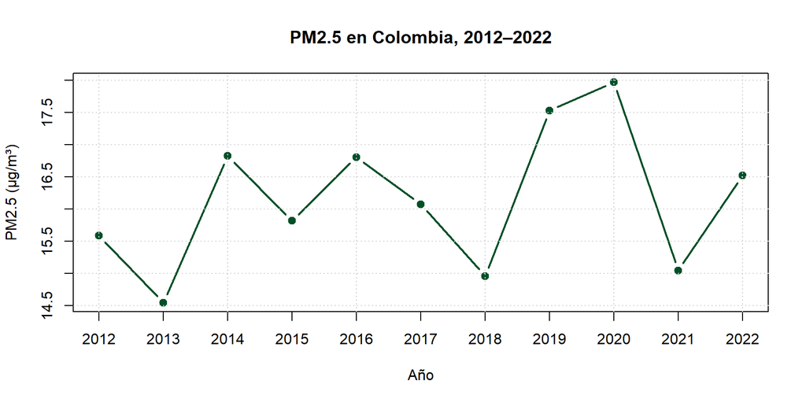

```r
plot(serie$anio,serie$media_pm25,type="b",pch=19,lwd=2,
     col="#005028",xlab="Año",ylab="PM2.5 (µg/m³)",
     main="PM2.5 en Colombia, 2012–2022",xaxt="n")
axis(1,at=serie$anio)
grid()
```

```r
ranking <- aggregate(PM25_area_valida~Departamento,panel,mean)
ranking <- ranking[order(-ranking$PM25_area_valida),]
knitr::kable(head(ranking,5),digits=2,
             caption="Mayores promedios departamentales, 2012–2022")
```

Mayores promedios departamentales, 2012–2022

|  | Departamento | PM25_area_valida |
| --- | --- | --- |
| 1 | Amazonas | 21.60 |
| 32 | Vaupés | 19.46 |
| 17 | Guainía | 18.54 |
| 5 | Atlántico | 18.30 |
| 29 | Sucre | 18.15 |

**Cómo leer estos resultados.** La serie resume promedios simples entre departamentos; por tanto, cada departamento aporta el mismo peso al promedio anual, independientemente de su población. El máximo se registra en 2020 (17,97 µg/m³) y el mínimo en 2013 (14,54 µg/m³). El ranking permite explorar diferencias territoriales, pero no debe interpretarse como clasificación de exposición individual.

# 4. Resultados espaciales auditados

## Cartografía comparativa

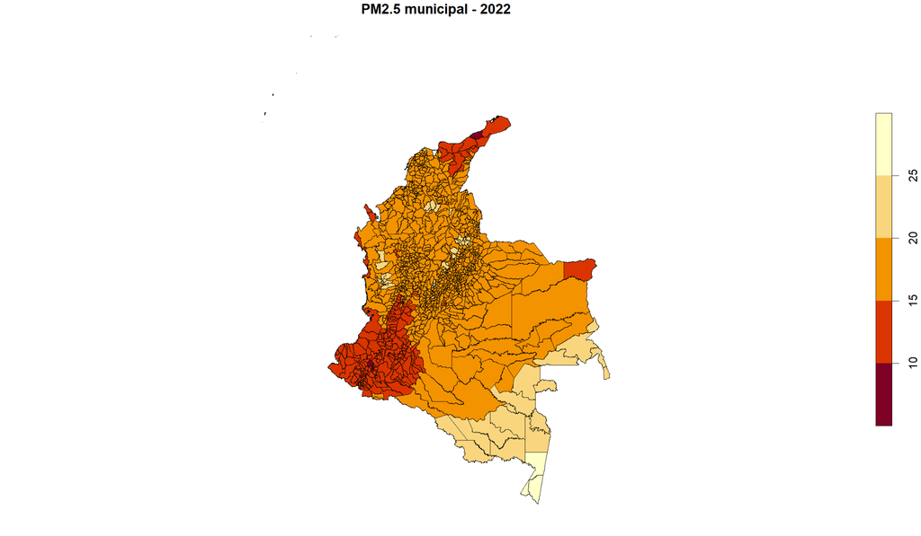

## Moran global

La validación original (informe 16B) utiliza vecindad Queen, 32 departamentos conectados y 9.999 permutaciones por año. San Andrés y Providencia no tiene vecinos por contigüidad. Los once años presentan autocorrelación global positiva significativa después de corrección por comparaciones múltiples.

```r
moran <- data.frame(
 anio=2012:2022,
 I=c(.3527717,.3860155,.2436526,.2458476,.3220304,.3430774,
     .3127660,.3276760,.4041887,.5864220,.3738347),
 p=c(.0005,.0009,.0127,.0083,.0016,.0009,.0030,.0015,.0001,.0001,.0007))
moran$p_BH_aprox <- p.adjust(moran$p,method="BH")
knitr::kable(moran,digits=5,
 caption="I y p del informe 16B; BH aproximado recalculado sobre p publicados")
```

I y p del informe 16B; BH aproximado recalculado sobre p publicados

| anio | I | p | p_BH_aprox |
| --- | --- | --- | --- |
| 2012 | 0.35277 | 0.0005 | 0.00165 |
| 2013 | 0.38602 | 0.0009 | 0.00165 |
| 2014 | 0.24365 | 0.0127 | 0.01270 |
| 2015 | 0.24585 | 0.0083 | 0.00913 |
| 2016 | 0.32203 | 0.0016 | 0.00220 |
| 2017 | 0.34308 | 0.0009 | 0.00165 |
| 2018 | 0.31277 | 0.0030 | 0.00367 |
| 2019 | 0.32768 | 0.0015 | 0.00220 |
| 2020 | 0.40419 | 0.0001 | 0.00055 |
| 2021 | 0.58642 | 0.0001 | 0.00055 |
| 2022 | 0.37383 | 0.0007 | 0.00165 |

**Importante:** los valores I y p se transcriben del informe de validación original, no se reestiman desde el CSV. El ajuste BH mostrado se calcula sobre valores p publicados y redondeados.

## LISA

El informe 17 documenta **dos observaciones significativas entre 352 contrastes**, con corrección Benjamini–Hochberg dentro de cada año: **Vaupés, alto–alto, 2020 y 2021**. Los resultados locales no deben confundirse con la significación global.

# 5. Integración del viento ERA5

```r
sin_viento <- panel[is.na(panel$viento_media_ms),
                   c("anio","Departamento","estado_viento")]
cat("Observaciones sin viento:",nrow(sin_viento),"\n")
```

```
## Observaciones sin viento: 11
```

```r
knitr::kable(sin_viento,caption="Ausencias meteorológicas documentadas")
```

Ausencias meteorológicas documentadas

|  | anio | Departamento | estado_viento |
| --- | --- | --- | --- |
| 27 | 2012 | Archipiélago de San Andrés y Providencia | SIN_DATO |
| 60 | 2013 | Archipiélago de San Andrés y Providencia | SIN_DATO |
| 93 | 2014 | Archipiélago de San Andrés y Providencia | SIN_DATO |
| 126 | 2015 | Archipiélago de San Andrés y Providencia | SIN_DATO |
| 159 | 2016 | Archipiélago de San Andrés y Providencia | SIN_DATO |
| 192 | 2017 | Archipiélago de San Andrés y Providencia | SIN_DATO |
| 225 | 2018 | Archipiélago de San Andrés y Providencia | SIN_DATO |
| 258 | 2019 | Archipiélago de San Andrés y Providencia | SIN_DATO |
| 291 | 2020 | Archipiélago de San Andrés y Providencia | SIN_DATO |
| 324 | 2021 | Archipiélago de San Andrés y Providencia | SIN_DATO |
| 357 | 2022 | Archipiélago de San Andrés y Providencia | SIN_DATO |

La integración meteorológica no constituye, por sí sola, evidencia de validez de una variable instrumental.

# 6. Mortalidad respiratoria y análisis exploratorio

La variable `Tasa_IRA_100mil_candidata` requiere cautela: las agrupaciones DANE 109 (2012–2015 y 2017), 108 (2018–2022) y la fuente especial de 2016 **no están homologadas documentalmente**.

```r
causas <- unique(panel[c("anio","Codigo_causa_DANE",
                          "estado_dato_IRA",
                          "comparable_IRA_109_108_verificada")])
knitr::kable(causas[order(causas$anio),],
             caption="Auditoría de la comparabilidad sanitaria")
```

Auditoría de la comparabilidad sanitaria

|  | anio | Codigo_causa_DANE | estado_dato_IRA | comparable_IRA_109_108_verificada |
| --- | --- | --- | --- | --- |
| 1 | 2012 | 109 | IRA_CANDIDATA_NO_HOMOLOGADA | FALSE |
| 34 | 2013 | 109 | IRA_CANDIDATA_NO_HOMOLOGADA | FALSE |
| 67 | 2014 | 109 | IRA_CANDIDATA_NO_HOMOLOGADA | FALSE |
| 100 | 2015 | 109 | IRA_CANDIDATA_NO_HOMOLOGADA | FALSE |
| 133 | 2016 | NA | SIN_DESGLOSE_IRA_2016 | FALSE |
| 166 | 2017 | 109 | IRA_CANDIDATA_NO_HOMOLOGADA | FALSE |
| 199 | 2018 | 108 | IRA_CANDIDATA_NO_HOMOLOGADA | FALSE |
| 232 | 2019 | 108 | IRA_CANDIDATA_NO_HOMOLOGADA | FALSE |
| 265 | 2020 | 108 | IRA_CANDIDATA_NO_HOMOLOGADA | FALSE |
| 298 | 2021 | 108 | IRA_CANDIDATA_NO_HOMOLOGADA | FALSE |
| 331 | 2022 | 108 | IRA_CANDIDATA_NO_HOMOLOGADA | FALSE |

```r
tasa_recalculada <- with(panel,Defunciones_IRA_candidata/Poblacion*100000)
dif <- max(abs(tasa_recalculada-panel$Tasa_IRA_100mil_candidata),
           na.rm=TRUE)
cat("Diferencia máxima de tasa:",format(dif,scientific=TRUE),"\n")
```

```
## Diferencia máxima de tasa: 1.98952e-13
```

```r
muestra <- panel[complete.cases(panel[c("PM25_area_valida",
                                     "Tasa_IRA_100mil_candidata")]),]
r <- cor(muestra$PM25_area_valida,muestra$Tasa_IRA_100mil_candidata)
cat("Correlación agrupada de Pearson:",round(r,7),"\n")
```

```
## Correlación agrupada de Pearson: 0.1436008
```

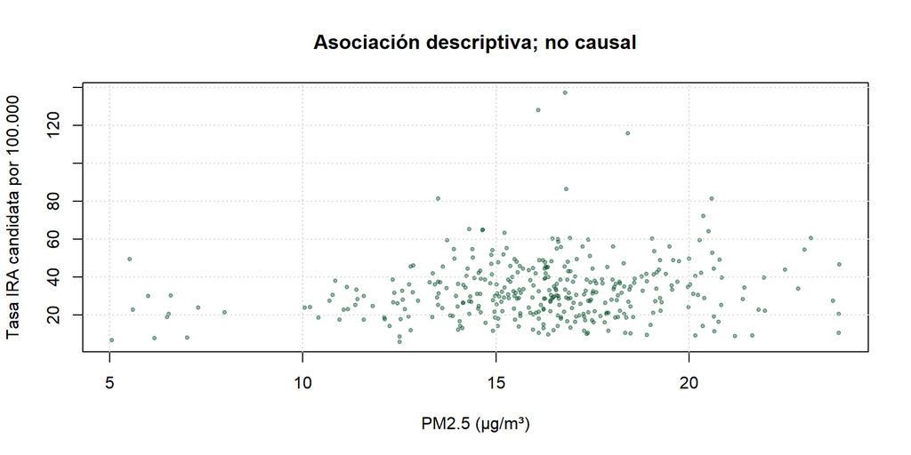

```r
plot(muestra$PM25_area_valida,muestra$Tasa_IRA_100mil_candidata,
     xlab="PM2.5 (µg/m³)",ylab="Tasa IRA candidata por 100.000",
     main="Asociación descriptiva; no causal",pch=19,cex=.55,
     col=adjustcolor("#005028",alpha.f=.4))
grid()
```

## Efectos fijos descriptivos

$$Tasa_{it}=\alpha_i+\lambda_t+\beta PM_{it}+\varepsilon_{it}.$$

```r
modelo <- lm(Tasa_IRA_100mil_candidata~PM25_area_valida+
               factor(dep_key)+factor(anio),data=muestra)
cat("Coeficiente descriptivo:",
    unname(coef(modelo)["PM25_area_valida"]),"\n")
```

```
## Coeficiente descriptivo: -0.001289048
```

```r
cat("Número de observaciones:",nobs(modelo),"\n")
```

```
## Número de observaciones: 363
```

El coeficiente no identifica un efecto causal. No se presenta estimación instrumental ni se afirma validez de sus supuestos. Los análisis originales documentan sensibilidad ante periodos y observaciones influyentes.